# LC-MS: from raw data to DM

Pietro Franceschi | pietro.franceschi@fmach.it

## Starting Ideas

1. Metabolites shows up as peaks in the rt/mz space
2. Each metabolites produces more than one peak
3. The peaks of the same compounds are slightly shifted in the different samples

## Fragmentation

During ionization chemical structures fragment in different ions

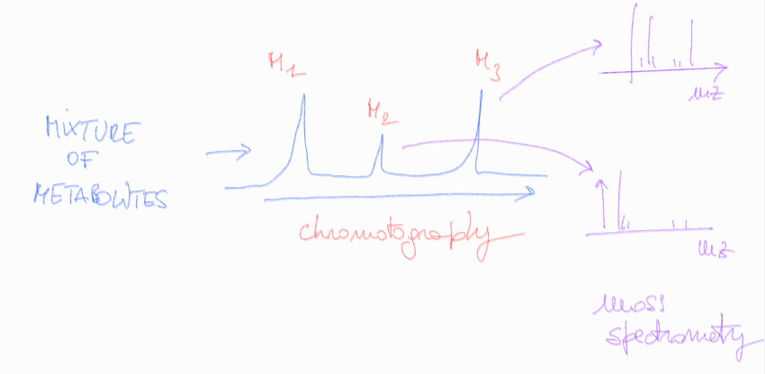

A metabolite **produce several peaks on the mz-rt plane**

## Extracted Ion Traces

The chromatograms of the ions coming from the same metabolite are locally correlated

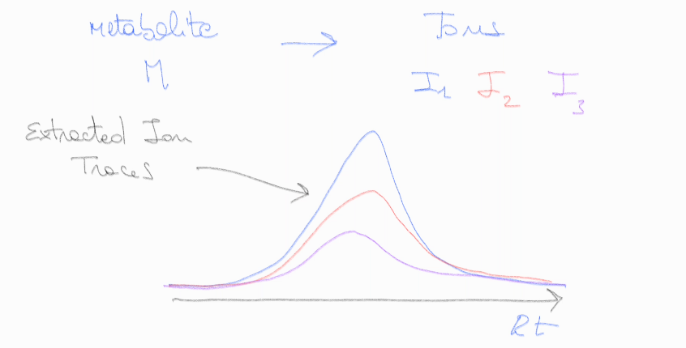

but the same ion can come from different metabolites!

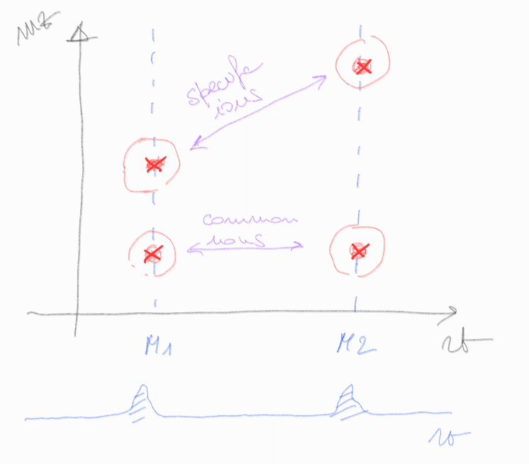

## Pre processing workflow

0. Get out the raw data from the proprietary format
1. Reliably find peaks in the 2D plane for each sample
2. Align the different peak lists correcting for **chromatographic drifts**
3. Match the peak lists across the samples find a consensus list of features
4. Select a good measure of intensity and arrange everything in a data matrix

**Provide reliable ways to visualize all the previous steps and check their consistency**

## Visualization

- Inspecting and checking the quality of each step
- Checking the outcomes of the statistical analysis

A result should be always visible in the raw data …

## On Instrumental drifts

- M/z value change because everything we measure changes …
- **Mass accuracy** (instrument property) defines the limits of m/z “drift”
- Chromatographic drifts are **less predictable** (at least for LC)
- Chromatographic drifts have various origin (time, age of the column, type of sample, …)
- The efficiency of the spectrometer degrades with time (the instrument gets dirty)

## 0. Get the raw data

Raw LC/Gc-MS are saved in **proprietary** format by the acquisition equipment (Bruker, Agilent, Thermo, Waters, …).

Before the analysis the raw data have to be **converted** into *open source* formats:

- mzData
- cdf
- mzXML
- **mzML** , more recent and recommended

Conversion tools

### Instrument software

- [*proteowizard*](http://proteowizard.sourceforge.net/)

# 1. Peak Picking

## General Ideas

**Look for peaks in the mz-rt plane**

Almost all software for the analysis of untargeted metabolomics data will propose different algorithms to perform peak picking:

- None of the algorithms is perfect
- There are a lot of parameters to tweak
- The practice (and **the awareness**) makes the master

## Matched Filter

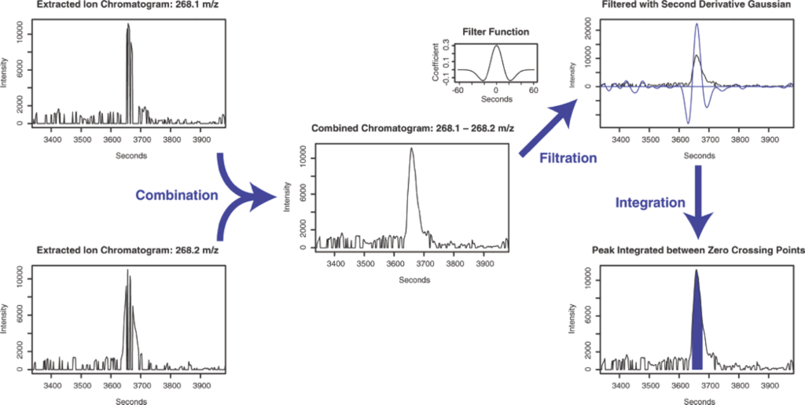

## Cent-Wave

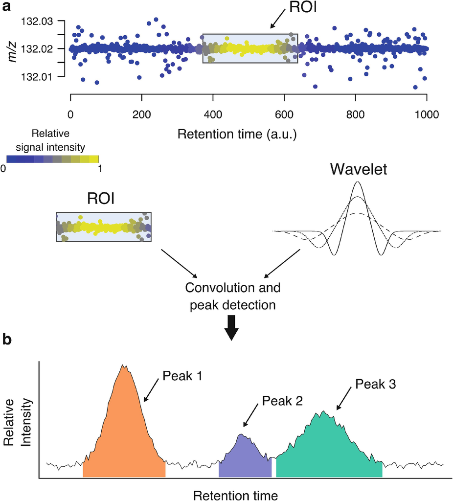

## Finding the best parameters

- Look for molecules you know should be there
- Visually Check your output
- Do no look for *perfection*
- Automatic solutions (reduce variability among the QC)

# 2. Alignment

## General Ideas

**The objective of alignment is to compensate the analytical drifts, without putting together things that should not be aligned**

In a multi sample experiment peak lists are

- different even if we analyze the same sample twice
- they are different for analytical/instrumental reasons
- they are different for biological reasons.
- in high rsolution experiments, `xcms` relies on [**obiwarp**](http://obi-warp.sourceforge.net/tutorials/mass_spectrometry_alignment_example.html)

# 3. Correspondance

## General Ideas

**The last step is to find a consensus list of variable across the different samples**

After alignment, the list of peaks is now aligned in retention time but:

- peak lists are still separated per sample
- a peak could be present only in a group of samples (because a metabolite is missing there)
- a peak could be missing because it was not correctly identified

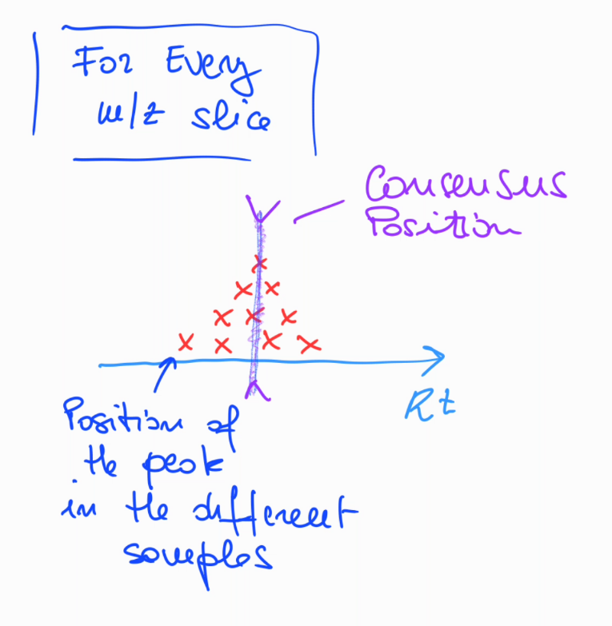

## Features and Peaks

- Peaks: show up in each sample at a specific time during chromatography due to the ionization of a metabolite
- Features: are consensus variables which group together different peaks

# 4. Get the DM

## Measuring Intensity

The actual signal intensity of each chromatographic peak (and then of each feature) can be characterized:

- by the area of the peak
- by the maximal intensity of the signal
- by the area of the filter used to find the peak

The area is often more robust, but can give erratic results if the peak is not well defined. The max intensity can be erratic. The signal of the filter is rarely used

## maxo - into

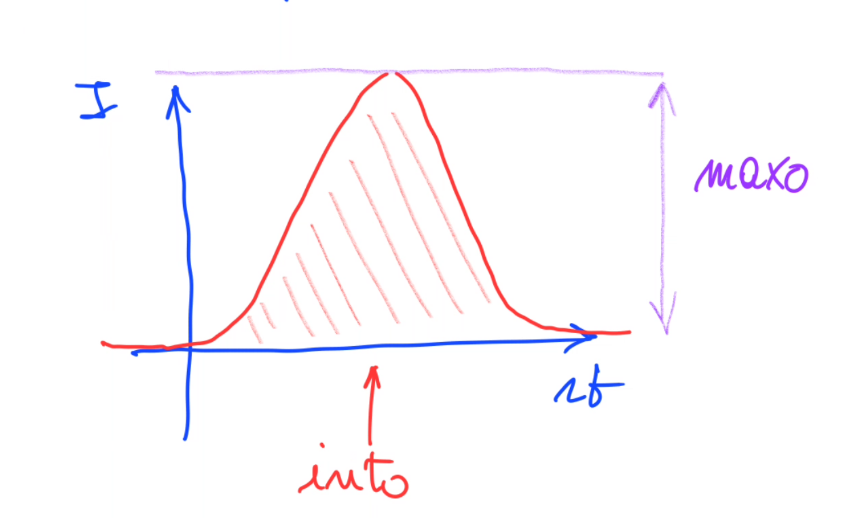

## Missing Features

Even if aligned the typical DM will be full of **missing values**

- error in peak picking
- error in alignment
- compound missing in one or more samples

## Imputation

- Remove the features with too many NAs
- The detection limit is unknown!
- Something related to the minimum intensity for each feature
- Something related to our knowledge of the instrument (noise)

**`xcms` implements a `fillPeaks()` function which will integrate the raw ms signal in the area of the peak in all missing samples**

- if the peak was missed the signal will be there
- if nothing was there only the noise will be integrated

## Feature filtering

**Some of the features will be measured in an unreliable way and should be discarded**

- features with too many missing values in the samples
- features showing an higher variability in the QC samples (high variability in QC than in true samples)
- …